# Covid_19_Prediction

### Categorical Variable

1. **Province/State**: This refers to the particular region of a nation, such as a state or province, where the data was collected. While some nations, including the US and Canada, do break out their data by region, this field is helpful for those who do.
2. **Country/Region**: The name of the nation or territory where COVID-19 instances are reported is displayed in the **Country/Region** column. It provides a more accurate location of the data when paired with the Province/State variable.
3. **WHO Region**: Countries are categorized by the World Health Organization (WHO) into areas such as the Americas, Africa, and Europe. This variable helps us compare COVID-19 trends across worldwide regions by indicating which WHO region each country.
4. **Date**: The day that the information was gathered. This field is essential for monitoring daily changes in cases, fatalities, recoveries, and active cases since COVID-19 is monitored over time.

### Numerical Variables

1. **Latitude**: The country or region's physical latitude coordinate is this. When combined with longitude, it facilitates the global mapping of COVID-19 cases.
2. **Longitude**: The country or region's geographic longitude coordinate is shown here. When combined with latitude, it makes it possible to map and visualize the COVID-19 outbreak.
3. **Confirmed**: The total number of confirmed COVID-19 cases in each region as of the specified date is displayed in this field. It aids in monitoring the virus's cross-region spread.
4. **Deaths**: The total number of COVID-19-related deaths in each location as of the specified date is stated in **Deaths**. It displays how severe the effect was in various locations.
5. **Recovered**: The total number of COVID-19 survivors in each region as of the displayed date is indicated in this field. It is helpful in determining the rate of recovery in various geogra p6ical areas.
6. **Active**: On the specified date, this indicates the total number of COVID-19 cases that are currently active in each location. It is determined by deducting recoveries and fatalities from the total number of confirmed cases. The current strain on healthcare systems across different locations is measured with the aid of this field.

##### Each of these domains supports in-depth analysis and cross-national comparisons, so contributing to a holistic perspective of COVID-19's worldwide inf in dence over time in depth analysis and comparisons across regions and countries.

### EXPLORATORY DATA ANALYSIS:

#### Loading the Data

##### To begin, we will import and examine the dataset in order to determine its structure. We'll probably examine the first few rows, search for any missing values, and verify the data types.

```python
# I start by importing the necessary libraries for data analysis and visualization.
import pandas as pd
import numpy as np
import matplotlib.pyplot as plt
import seaborn as sns

# Setting Seaborn style for better visuals
sns.set(style="whitegrid")

# Loading the CSV file
data = pd.read_csv("/content/covid-19_data.csv")

# Showing the first few rows of the data to understand its structure
data.head()
```

|  | Province/State | Country/Region | Latitude | Longitude | Date | Confirmed | Deaths | Recovered | Active | WHO Region |
| --- | --- | --- | --- | --- | --- | --- | --- | --- | --- | --- |
| 0 | NaN | Afghanistan | 33.93911 | 67.709953 | 1/22/2020 | 0 | 0 | 0 | 0 | Eastern Mediterranean |
| 1 | NaN | Albania | 41.15330 | 20.168300 | 1/22/2020 | 0 | 0 | 0 | 0 | Europe |
| 2 | NaN | Algeria | 28.03390 | 1.659600 | 1/22/2020 | 0 | 0 | 0 | 0 | Africa |
| 3 | NaN | Andorra | 42.50630 | 1.521800 | 1/22/2020 | 0 | 0 | 0 | 0 | Europe |
| 4 | NaN | Angola | -11.20270 | 17.873900 | 1/22/2020 | 0 | 0 | 0 | 0 | Africa |

#### Basic Information and Data Types

##### Now, I’ll examine the dataset’s structure, including column types and any missing values. This will help in knowing what data cleaning might be necessary.

```python
# I’m checking for general information, including data types and missing values.
data.info()
```

```
<class 'pandas.core.frame.DataFrame'>
RangeIndex: 49068 entries, 0 to 49067
Data columns (total 10 columns):
 #   Column          Non-Null Count  Dtype
---  ------          --------------  -----
 0   Province/State  14664 non-null  object
 1   Country/Region  49068 non-null  object
 2   Latitude        49068 non-null  float64
 3   Longitude       49068 non-null  float64
 4   Date            49068 non-null  object
 5   Confirmed       49068 non-null  int64
 6   Deaths          49068 non-null  int64
 7   Recovered       49068 non-null  int64
 8   Active          49068 non-null  int64
 9   WHO Region      49068 non-null  object
dtypes: float64(2), int64(4), object(4)
memory usage: 3.7+ MB
```

#### Checking Missing Values : (As it can effect the analysis)

```python
missing_values = data.isnull().sum()
missing_values[missing_values > 0]
```

|  | 0 |
| --- | --- |
| Province/State | 34404 |

**dtype:** int64

```python
# I calculate basic statistics to understand the spread and central tendencies of numerical data.
data.describe()
```

|  | Latitude | Longitude | Confirmed | Deaths | Recovered | Active |
| --- | --- | --- | --- | --- | --- | --- |
| count | 49068.000000 | 49068.000000 | 4.906800e+04 | 49068.000000 | 4.906800e+04 | 4.906800e+04 |
| mean | 21.433730 | 23.528236 | 1.688490e+04 | 884.179160 | 7.915713e+03 | 8.085012e+03 |
| std | 24.950320 | 70.442740 | 1.273002e+05 | 6313.584411 | 5.480092e+04 | 7.625890e+04 |
| min | -51.796300 | -135.000000 | 0.000000e+00 | 0.000000 | 0.000000e+00 | -1.400000e+01 |
| 25% | 7.873054 | -15.310100 | 4.000000e+00 | 0.000000 | 0.000000e+00 | 0.000000e+00 |
| 50% | 23.634500 | 21.745300 | 1.680000e+02 | 2.000000 | 2.900000e+01 | 2.600000e+01 |
| 75% | 41.204380 | 80.771797 | 1.518250e+03 | 30.000000 | 6.660000e+02 | 6.060000e+02 |
| max | 71.706900 | 178.065000 | 4.290259e+06 | 148011.000000 | 1.846641e+06 | 2.816444e+06 |

##### The above statistics like mean, median, min, and max, which will help me spot any outliers or unexpected values.

#### Visualizing the Global Distribution of Cases

##### Using latitude and longitude, i am now creating a scatter plot of cases worldwide. This type of visualization gives a quick look at how cases are spread geographically.

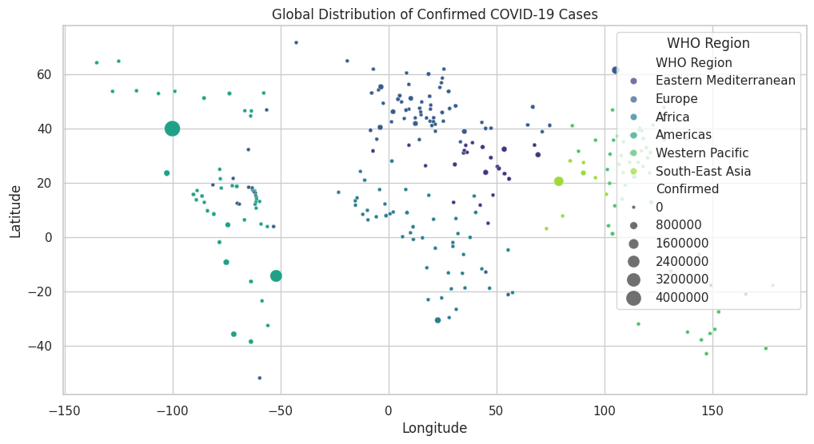

```python
# For Basic view, I plot a map of the world to show the distribution of COVID-19 cases across different regions.
plt.figure(figsize=(12, 6))
sns.scatterplot(x='Longitude', y='Latitude', size='Confirmed', hue='WHO Region',
                sizes=(10, 200), data=data, palette="viridis", alpha=0.7)
plt.title("Global Distribution of Confirmed COVID-19 Cases")
plt.xlabel("Longitude")
plt.ylabel("Latitude")
plt.legend(loc='upper right', title="WHO Region")
plt.show()
```

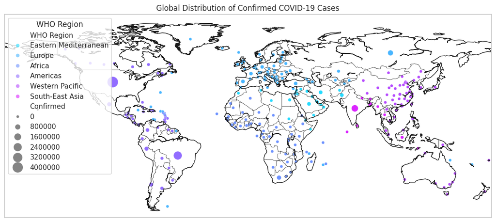

```python
!pip install basemap

## I am using this to create much better visualizations.
## This shows top few countries where the rates were much higher.
## We can identify the countries through this visualization.

from mpl_toolkits.basemap import Basemap
import matplotlib.pyplot as plt
import seaborn as sns

# Initialize Basemap with world view
plt.figure(figsize=(14, 8))
m = Basemap(projection='cyl', llcrnrlat=-60, urcrnrlat=90,
            llcrnrlon=-180, urcrnrlon=180, resolution='c')

# Draw coastlines and country borders
m.drawcoastlines()
m.drawcountries()

# Scatter plot for confirmed cases, sized by 'Confirmed' and colored by 'WHO Region'
sns.scatterplot(
    x='Longitude', y='Latitude', size='Confirmed', hue='WHO Region',
    sizes=(20, 300), data=data, palette="cool", alpha=0.6
)

plt.title("Global Distribution of Confirmed COVID-19 Cases")
plt.xlabel("Longitude")
plt.ylabel("Latitude")
plt.legend(loc='upper left', title="WHO Region")
plt.show()
```

#### Now Analyzing Trends Over Time

##### Now, we’ll look at how cases changed over time. I think grouping by Date will allow us to create a time-series plot showing trends in Confirmed, Deaths, and Recovered cases.

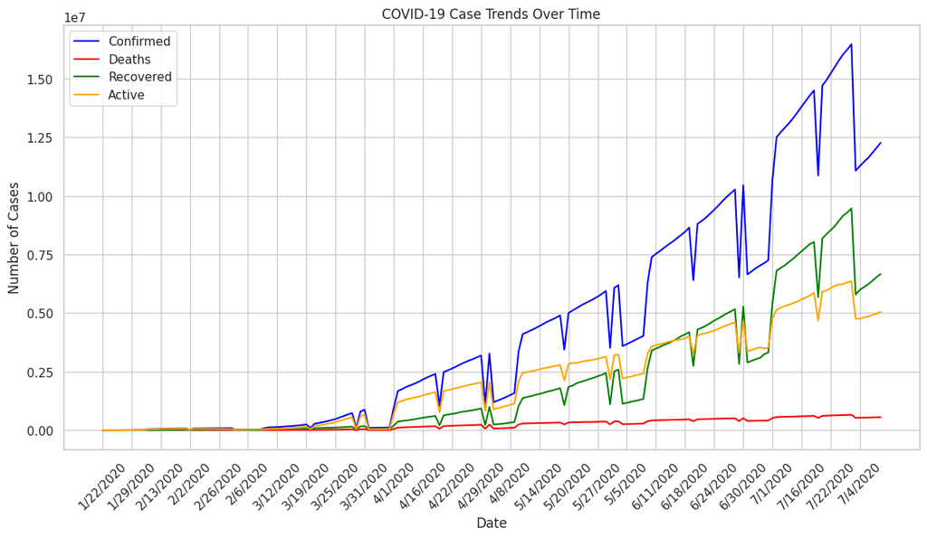

```python
# I group the data by Date and sum up the cases to see trends over time.
time_data = data.groupby('Date')[['Confirmed', 'Deaths', 'Recovered', 'Active']].sum().reset_index()

# Plotting the trend over time
plt.figure(figsize=(14, 7))
plt.plot(time_data['Date'], time_data['Confirmed'], label="Confirmed", color='blue')
plt.plot(time_data['Date'], time_data['Deaths'], label="Deaths", color='red')
plt.plot(time_data['Date'], time_data['Recovered'], label="Recovered", color='green')
plt.plot(time_data['Date'], time_data['Active'], label="Active", color='orange')

plt.title("COVID-19 Case Trends Over Time")
plt.xlabel("Date")
plt.ylabel("Number of Cases")
plt.legend()
plt.xticks(ticks=range(0, len(time_data['Date']), 7), labels=time_data['Date'][::7], rotation=45)
plt.show()
```

#### Analyzing Active Cases by WHO Region

##### From this analysis we can understand which WHO regions are currently most impacted. We’ll look at the distribution of active cases by region using a bar plot.

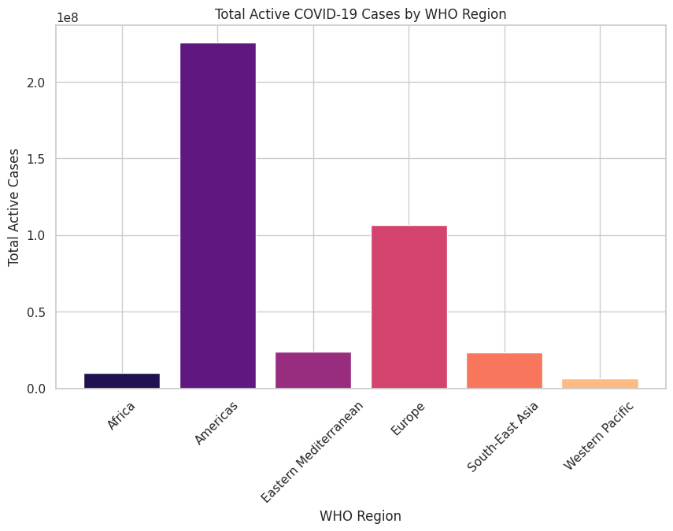

```python
# Plotting active cases by WHO region with manually assigned colors
plt.figure(figsize=(10, 6))
if 'WHO Region' in data.columns and 'Active' in data.columns:
    # Group data by WHO Region and sum up active cases
    region_data = data.groupby('WHO Region')['Active'].sum()

    # Plotting active cases by WHO region
    plt.figure(figsize=(10, 6))
    bars = plt.bar(region_data.index, region_data.values, color=sns.color_palette("magma", len(region_data)))

    # Adding labels and title
    plt.title("Total Active COVID-19 Cases by WHO Region")
    plt.xlabel("WHO Region")
    plt.ylabel("Total Active Cases")
    plt.xticks(rotation=45)
    plt.show()
else:
    print("The necessary columns 'WHO Region' and 'Active' are not present in the dataset.")
```

#### Relationship Between Confirmed Cases and Deaths

##### To understand the severity of COVID-19, we can look at the relationship between confirmed cases and deaths. A scatter plot with a regression line will show if there’s a strong correlation between the two.

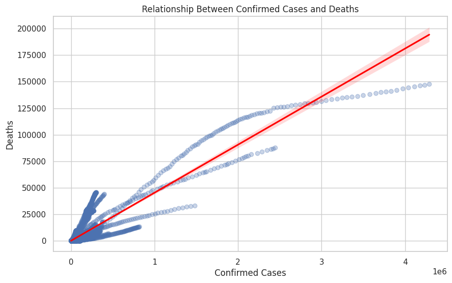

```python
# Plotting the relationship between Confirmed and Deaths
plt.figure(figsize=(10, 6))
sns.regplot(x='Confirmed', y='Deaths', data=data, scatter_kws={'alpha':0.3}, line_kws={"color":"red"})
plt.title("Relationship Between Confirmed Cases and Deaths")
plt.xlabel("Confirmed Cases")
plt.ylabel("Deaths")
plt.show()
```

#### Understanding the COVID-19 dataset is made easier by this EDA. We might then examine comparisons between nations in greater detail or even examine long-term patterns within certain nations more too.

### ETL PROCESS

It involves Extracting, Transforming and Loading the data.

Step 1: We have extracted the data in the above steps

```python
#Step 2: Transforming

#I have converted Date colum to datetime format
data['Date'] = pd.to_datetime(data['Date'])

# I have filled missing 'Province/State' with "Unknown"
data['Province/State'].fillna("Unknown", inplace=True)

# Removed duplicate rows if any
data.drop_duplicates(inplace=True)

# Calculated additional columns (e.g., Case Fatality Rate and Recovery Rate)
data['Case_Fatality_Rate'] = (data['Deaths'] / data['Confirmed']).replace([np.inf, -np.inf], np.nan).fillna(0)
data['Recovery_Rate'] = (data['Recovered'] / data['Confirmed']).replace([np.inf, -np.inf], np.nan).fillna(0)

# Filtered data for meaningful analysis (e.g., remove rows with 0 confirmed cases)
filtered_data = data[data['Confirmed'] > 0]
```

```python
#Step 3: Load the dataset

filtered_data.to_csv("transformed_covid_data.csv", index=False)
print("ETL process completed. Transformed data saved to 'transformed_covid_data.csv'.")
```

```
ETL process completed. Transformed data saved to 'transformed_covid_data.csv'.
```

```python
#Now load the transformed dataset

# Loading the CSV file
t_data = pd.read_csv("/content/transformed_covid_data.csv")

# Showing the first few rows of the data to understand its structure
t_data.head()
```

|  | Province/State | Country/Region | Latitude | Longitude | Date | Confirmed | Deaths | Recovered | Active | WHO Region | Case_Fatality_Rate | Recovery_Rate |
| --- | --- | --- | --- | --- | --- | --- | --- | --- | --- | --- | --- | --- |
| 0 | Anhui | China | 31.8257 | 117.2264 | 2020-01-22 | 1 | 0 | 0 | 1 | Western Pacific | 0.0 | 0.0 |
| 1 | Beijing | China | 40.1824 | 116.4142 | 2020-01-22 | 14 | 0 | 0 | 14 | Western Pacific | 0.0 | 0.0 |
| 2 | Chongqing | China | 30.0572 | 107.8740 | 2020-01-22 | 6 | 0 | 0 | 6 | Western Pacific | 0.0 | 0.0 |
| 3 | Fujian | China | 26.0789 | 117.9874 | 2020-01-22 | 1 | 0 | 0 | 1 | Western Pacific | 0.0 | 0.0 |
| 4 | Guangdong | China | 23.3417 | 113.4244 | 2020-01-22 | 26 | 0 | 0 | 26 | Western Pacific | 0.0 | 0.0 |

### MODEL BUILDING

For model building I have considered two models, i.e.,

Random forest and Support Vector Machine

Why Both Models?

Random Forest was selected for its stability, efficiency in modeling non-linearity nature of the data and for feature importance analysis, while SVM was preferred for its non-parametric kernel technique to model the non-linear pattern of the data and do an effective comparison of ensemble and kernel based approaches.

```python
#Random forest model

from sklearn.model_selection import train_test_split
from sklearn.ensemble import RandomForestRegressor
from sklearn.metrics import mean_squared_error, r2_score
from sklearn.metrics import f1_score

t_data = pd.read_csv("/content/transformed_covid_data.csv")


# Feature Selection
X = t_data[['Confirmed', 'Recovered', 'Active']]
y = t_data['Deaths']

# Train-Test Split
X_train, X_test, y_train, y_test = train_test_split(X, y, test_size=0.2, random_state=42)

# Model Initialization
model = RandomForestRegressor(random_state=42, n_estimators=100)

# Train the model
model.fit(X_train, y_train)

# Predictions
y_pred = model.predict(X_test)

# Evaluate the model
mse = mean_squared_error(y_test, y_pred)
r2 = r2_score(y_test, y_pred)

print(f"Model Performance:\nMean Squared Error: {mse}\nR^2 Score: {r2}")

# Feature Importance
importances = model.feature_importances_
feature_names = X.columns
importance_df = pd.DataFrame({'Feature': feature_names, 'Importance': importances}).sort_values(by='Importance', ascending=False)
print("Feature Importances:")
print(importance_df)


#define the threshold to convert into binary
threshold = 500

# Binarize the target variable
y_binary = (y > threshold).astype(int)

# Predict continuous values
rf_predictions = model.predict(X_test)
# Convert predictions to binary classes
rf_binary_predictions = (rf_predictions > threshold).astype(int)
# Calculate F1 score
rf_f1 = f1_score((y_test > threshold).astype(int), rf_binary_predictions)
print(f"Random Forest Regressor F1 Score: {rf_f1}")
```

```
Model Performance:
Mean Squared Error: 557105.5875767752
R^2 Score: 0.9901338545512457
Feature Importances:
     Feature  Importance
2     Active    0.494170
0  Confirmed    0.452454
1  Recovered    0.053376
Random Forest Regressor F1 Score: 0.9179793590439979
```

```python
#Support Vector Machine

from sklearn.svm import SVR
from sklearn.preprocessing import StandardScaler
from sklearn.inspection import permutation_importance


# Load the transformed data
t_data = pd.read_csv("/content/transformed_covid_data.csv")

# Feature Selection
X = t_data[['Confirmed', 'Recovered', 'Active']]
y = t_data['Deaths']

# Standardize the features for SVM
scaler = StandardScaler()
X_scaled = scaler.fit_transform(X)

# Train-Test Split
X_train, X_test, y_train, y_test = train_test_split(X_scaled, y, test_size=0.2, random_state=42)

# Initialize and train the SVM model
svm_model = SVR(kernel='rbf', C=1.0, epsilon=0.2)
svm_model.fit(X_train, y_train)

# Predict continuous values using the trained SVM model
svm_predictions = svm_model.predict(X_test)

# Convert SVM predictions to binary classes for F1 Score calculation
svm_binary_predictions = (svm_predictions > threshold).astype(int)
y_test_binary = (y_test > threshold).astype(int)

# Metrics Calculation
mse = mean_squared_error(y_test, svm_predictions)
r2 = r2_score(y_test, svm_predictions)
f1 = f1_score(y_test_binary, svm_binary_predictions)

print(f"SVM Model Performance:")
print(f"Mean Squared Error: {mse}")
print(f"R-squared: {r2}")


# Feature Importance - Equivalent using coefficients
# Calculate Permutation Importance
perm_importance = permutation_importance(svm_model, X_test, y_test, n_repeats=10, random_state=42)

# Feature Importance DataFrame
importance_df = pd.DataFrame({
    'Feature': ['Confirmed', 'Recovered', 'Active'],
    'Importance': perm_importance.importances_mean
}).sort_values(by='Importance', ascending=False)

print("\nFeature Importances (Permutation Importance):")
print(importance_df)

print(f"F1 Score: {f1}")
```

```
SVM Model Performance:
Mean Squared Error: 55050613.12568545
R-squared: 0.025072861854463224

Feature Importances (Permutation Importance):
     Feature  Importance
0  Confirmed    0.006465
1  Recovered    0.006035
2     Active    0.004289
F1 Score: 0.6901694915254237
```

### Observation

Based on the results gained during the analyses one can observe an array of substantial discrepancies in the decision-making algorithm of the Random Forest Regressor compared to the Support Vector Machine (SVM). Random Forest is much better than the other models in term of MSE with having MSE = 557,105.59, and having very high r-squared coefficient of determination of 0.99 shows that it has predictive value of 99% of the variances of the target variable. In addition, it has an F-measure of 0.9179 to show how well it can classify when the regression prediction is in binary classes. Analyzing the ranking of features, Active cases occupy the highest place as an influential indicator, which is 49.4%, while Confirmed cases reach 45.2%, and finally, Recovered cases take only 5.3%.

### Exploratory Data Analysis

### Structure of the Dataset:

The dataset has columns like Confirmed, Deaths, Recovered, Active, Country/Region, and WHO Region. Another issue that was noted is the presence of missing values in the Province/State column, and these should be dealt with appropriately for optimal analysis.

Global Distribution: Scatter plots demonstrated how COVID-19 cases are spread in different geographical locations all over the world using the latitude and longitude co-ordinates. Larger bubbles meant more confirmed case rates in certain areas.

Basic Statistics: Preliminary analysis of COVID-19 indicators showed that they may vary greatly depending on the region. For example: Large standard deviation in confirmed case indicates large variability in the number of cases across the regions. Inspection of active cases and death count provided outliers, which might be due to greater contagious areas with more deaths.

Missing Values: Some of the values may be missing in the Province/State column because the certain countries do not report regional data.

Insights from the Models:

Random Forest Regressor Performance:

R-square = 0.99: There is yet still an outstanding regression performance; the current model has almost zero error explaining 99% of variance in the data.

MSE: 557,105.59; what still could be considered as a quite low error for the given sample.

F1 Score: 0.9179, it can be seen that the algorithm exhibits high degree of classification accuracy when the binary prediction results are employed.

Feature Importance:

Active Cases is the most predictive factor to Deaths by 49.4% trailed by Confirmed Cases by 45.2%. Recovered Cases contribute very less (5.3%).

Support Vector Machine (SVM) Performance:

R-square = 0.025: It reveals that SVM has an inability of explaining variation in the target variable.

MSE: Its regression accuracy is significantly low as compared to Random Forest as shown 55,050,613.13.

F1 Score: 0.6901, which is less than Random Forest.

Feature Importance (Permutation Importance): Individual features examined here revealed that all of them exhibited marginal improvements to the model, implying that in general, SVM was not effective at learning relationships in the given data.

### Conclusion:

Based on the dataset and models used, the following conclusions can be drawn:

Impact of COVID-19:

The dataset shows that there are large deviations in totals of confirmed cases, deaths, and recoveries between the regions. Countries or regions with more active cases are more at risk given that active cases have a straight-forward relationship with deaths.

Model Performance:

The Random Forest Regressor model is most accurate for this dataset. It gives good accuracy, interpretability of feature importance, and very good behaviour in terms of classification.

Again, in SVM we had great results only when the parameters were nicely tuned which was not the case here and the high variance in the data could not be handled properly by SVM.

Feature Importance:

Our results show that Active Cases and Confirmed Cases have the highest correlation with COVID-19 deaths, identifying ongoing infections and the total impact in the determination of the mortality rate.

### To predict if a COVID-19 case would result in recovery or death using Active Cases and Confirmed Cases among other features.

Target:

Class 0: Death cases dominate, that is deaths ≥ recoveries.

Class 1: Recovery cases dominate, that is recoveries > deaths.

Target Creation:

Cases with higher number of recoveries than deaths are considered as 1, recovery dominant.

Cases where the number of deaths is greater than or equal to the recoveries are considered as 0, death dominant.

Features:

Active Cases:

It characterizes active infections and also a load on medical institutions. Confirmed Cases: It reflects the overall exposure and the accumulated spread. Model A Random Forest Classifier is trained on the classification target. The model uses data from January to June for training and July data for testing. Evaluation Metrics Classification Report: This provides precision, recall, F1-score, and overall accuracy for both classes.

Confusion Matrix:

Visualizes the number of correct predictions, both positive and negative, and the number of incorrect predictions, both false positives and false negatives.

```python
import pandas as pd
from sklearn.ensemble import RandomForestClassifier
from sklearn.metrics import classification_report, confusion_matrix

# Load the dataset
data = pd.read_csv("/content/transformed_covid_data.csv")

# Convert 'Date' to datetime
data['Date'] = pd.to_datetime(data['Date'])

# Filter data from January to June for training
train_data = data[(data['Date'] >= '2020-01-01') & (data['Date'] <= '2020-06-30')]

# Define features (Active, Confirmed) and target (binary classification: Recovered > Deaths)
train_data['Target'] = (train_data['Recovered'] > train_data['Deaths']).astype(int)

# Prepare the training dataset
X_train = train_data[['Active', 'Confirmed']]
y_train = train_data['Target']

# Filter July data for testing
test_data = data[(data['Date'] >= '2020-07-01') & (data['Date'] <= '2020-07-31')]
X_test = test_data[['Active', 'Confirmed']]
y_test = (test_data['Recovered'] > test_data['Deaths']).astype(int)

# Train the RandomForestClassifier
rf_classifier = RandomForestClassifier(random_state=42, n_estimators=100)
rf_classifier.fit(X_train, y_train)

# Predict using July data
y_pred = rf_classifier.predict(X_test)

# Evaluate model performance
print("Classification Report for July Data:")
print(classification_report(y_test, y_pred))

print("Confusion Matrix for July Data:")
print(confusion_matrix(y_test, y_pred))
```

```
Classification Report for July Data:
              precision    recall  f1-score   support

           0       0.92      0.73      0.81       548
           1       0.98      0.99      0.99      6499

    accuracy                           0.97      7047
   macro avg       0.95      0.86      0.90      7047
weighted avg       0.97      0.97      0.97      7047

Confusion Matrix for July Data:
[[ 399  149]
 [  33 6466]]
```

### Results and Insights:

### Classification Report:

Predicted Recovery (Class 1):

Recoveries dominate in these cases.

F1-score: 0.99 - Excellent performance for recoveries.

Predicted Death (Class 0):

Deaths dominate in these cases.

F1-score: 0.81 - Slightly lower performance compared to recovery predictions.

Confusion Matrix:

True Positives (Class 1):

6,466 cases were correctly predicted as recoveries.

True Negatives (Class 0):

399 cases were correctly predicted as deaths.

False Positives (Class 1 predicted but actually Class 0):

149 cases were predicted to be recoveries when they actually died.

False Negatives (Class 0 predicted but actually Class 1):

33 cases were predicted to die when they actually recovered.

### Summary:

This model has achieved an accuracy of 97% and hence can be highly reliable in terms of prediction regarding the outcome of a recovery case.

Predictions for death cases are a bit less accurate, but the model shows strong overall performance and reliability.